# Real-world R for Actuaries

Visualising Data

Mick Cooney mcooney@describedata.com

2019-04-08

# 1 Visualising Data

Data visualisations is the single most powerful tool for data exploration and analysis - one that is often over-looked and under-appreciated.

## 1.1 Our First Visualisations

Our first visualisation is going to be a simple one: we plot the most updated value of each claim from Ireland over time. The dataset `claims_snapshot_tbl` is summarised version of our main dataset that contains this data.

### 1.1.1 Point Plots

Focusing on Irish claims from 2010, We look at the lifetime of the claim against the size of the amount, colouring the points by the claim type (`PD` or `BI`).

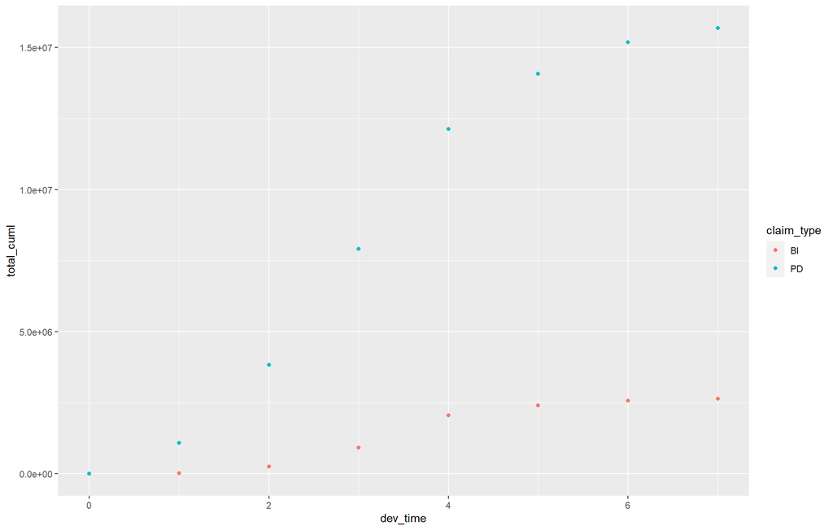

```r
plot_tbl <- claim_triangles_tbl %>%
  filter(country_code == 'IRL',
         claim_year   == 2010
         )

ggplot(plot_tbl) +
  geom_point(aes(x = dev_time, y = total_cuml, colour = claim_type))
```

### 1.1.2 Lineplots

Line plots are created in a similar fashion. In this plot, we show how aggregate claims develop over time.

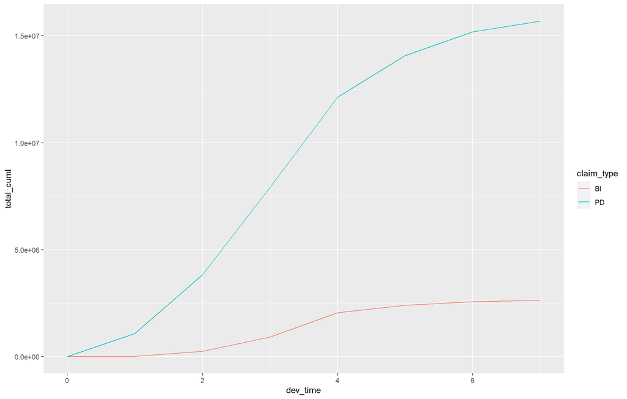

```r
plot_tbl <- claim_triangles_tbl %>%
  filter(country_code == 'IRL',
         claim_year   == 2010
         )

ggplot(plot_tbl) +
  geom_line(aes(x = dev_time, y = total_cuml, colour = claim_type))
```

### 1.1.3 Histograms

Histograms are a common way to understand how a value is distributed.

To start, we inspect the distribution of BI claim sizes for Ireland in 2010.

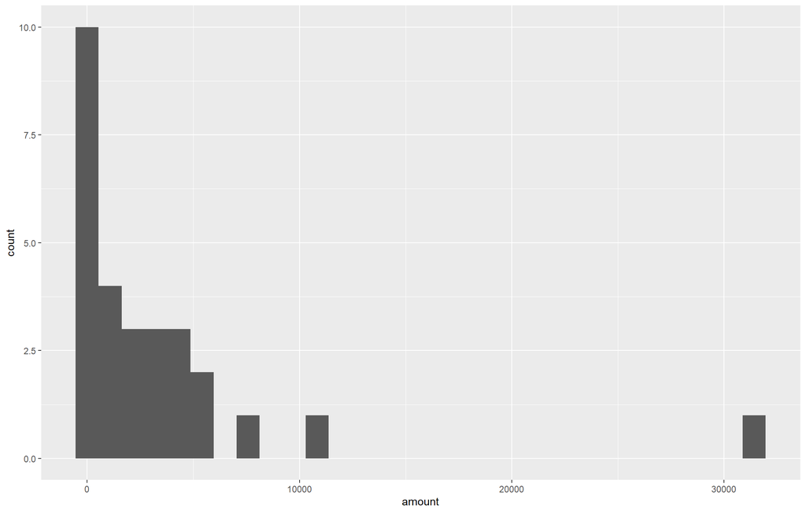

```r
plot_tbl <- claim_snapshot_tbl %>%
  filter(country_code == 'IRL',
         year         == 2010,
         claim_type   == 'BI'
         )

ggplot(plot_tbl) +
  geom_histogram(aes(x = amount))
```

By default, the histogram is built from 30 bins, but we can control this directly if we wish.

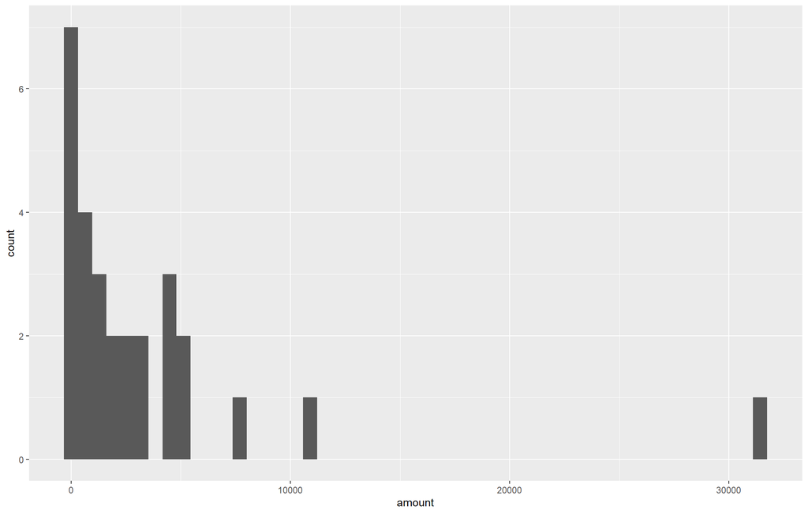

```r
ggplot(plot_tbl) +
  geom_histogram(aes(x = amount), bins = 50)
```

### 1.1.4 Boxplots

`ggplot2` provides a uniform interface for all its plot types. To illustrate this, we look at the most recent BI claim values for Ireland in 2010 and create a boxplot.

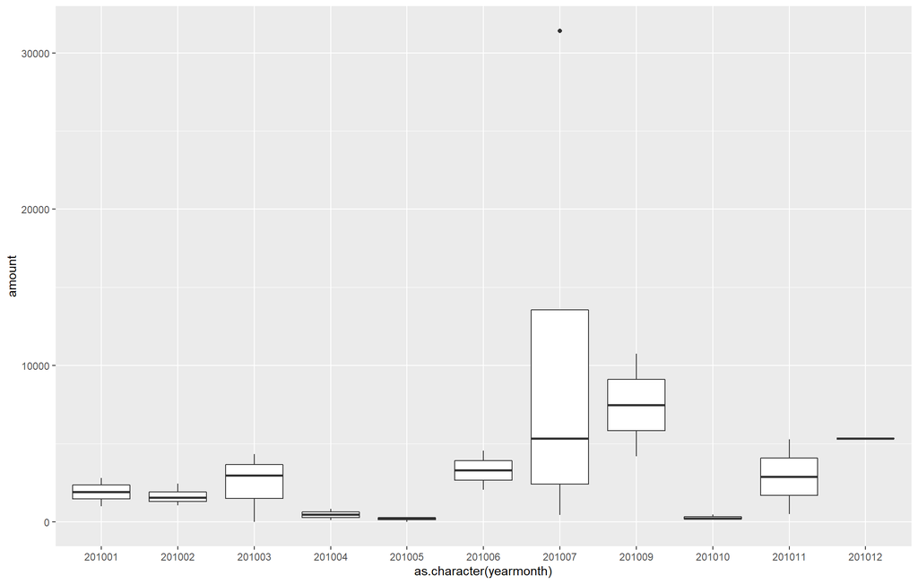

```r
plot_tbl <- claim_snapshot_tbl %>%
  filter(country_code == 'IRL',
         year         == 2010,
         claim_type   == 'BI'
         )

ggplot(plot_tbl) +
  geom_boxplot(aes(x = as.character(yearmonth), y = amount))
```

We can also plot the two claim types beside each other at the same time.

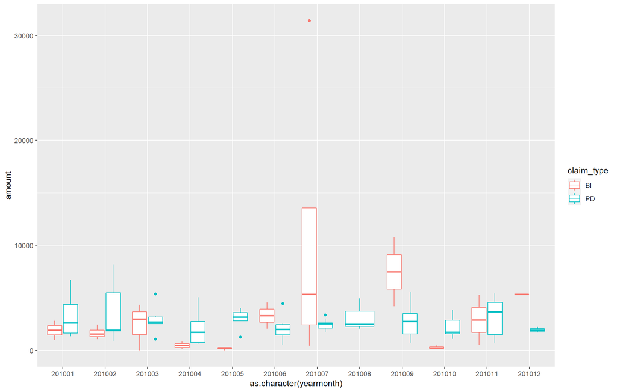

```r
plot_tbl <- claim_snapshot_tbl %>%
  filter(country_code == 'IRL',
         year         == 2010
         )

ggplot(plot_tbl) +
  geom_boxplot(aes(x = as.character(yearmonth), y = amount, colour = claim_type))
```

### 1.1.5 Exercises

- Create a point plot for UK claims (country code ‘GBR’) for the year 2012.
- Change the original plot to change both shape and colour depending on type of claim.
- Change the BI boxplot to show ‘PD’ claims.
- Create the combined boxplot for BI claims in 2010 showing both ‘IRL’ and ‘GBR’ claims with different colours.
- Create a point plot for IRL claims for all years since 2010.
- Improve the visibility of the data by using the `alpha` parameter.

## 1.2 Improving Visualisations

We now build on our basic understanding of plotting to look for ways to improve our visualisations.

### 1.2.1 Facets

Sometimes visualisations are improved by the use of *facets* - we have segment the data into groups and plot those beside each other.

To start, we look at the development of aggregate claims for 2010 for the UK, Germany, France and Italy.

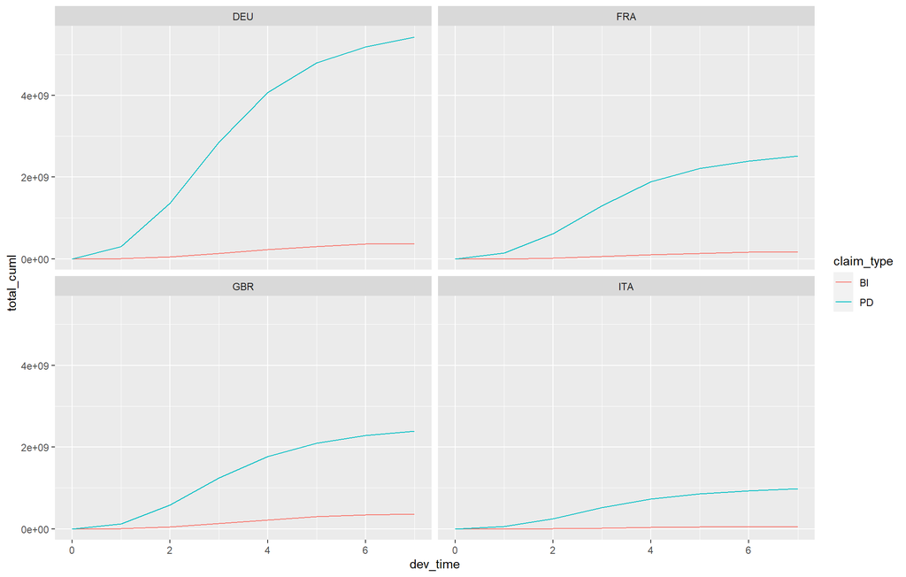

```r
plot_tbl <- claim_triangles_tbl %>%
  filter(country_code %in% c('GBR', 'DEU', 'FRA', 'ITA'),
         claim_year   == 2010
         )

ggplot(plot_tbl) +
  geom_line(aes(x = dev_time, y = total_cuml, colour = claim_type)) +
  facet_wrap(~ country_code)
```

By default with facetting we have a common scale, and this can obscure things, so we now allow each facet to have its own y-axis:

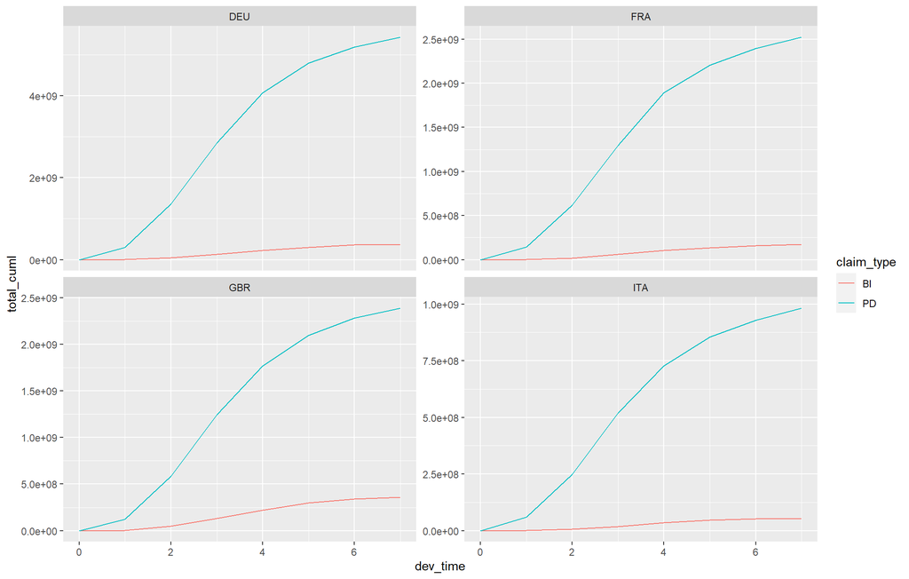

```r
ggplot(plot_tbl) +
  geom_line(aes(x = dev_time, y = total_cuml, colour = claim_type)) +
  facet_wrap(~ country_code, scales = 'free_y')
```

It is also possible to facet in two dimensions, say be country and claim type

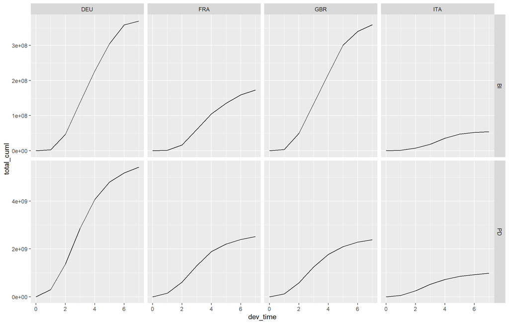

```r
ggplot(plot_tbl) +
  geom_line(aes(x = dev_time, y = total_cuml)) +
  facet_grid(claim_type ~ country_code, scales = 'free_y')
```

### 1.2.2 Multiple Geoms

We can add multiple ‘geoms’ one one graph, such as adding the points as well as the lines.

Going back to the original plot, here is how we plot the development of the aggregate claims for Ireland in 2010 with both points and lines.

Note the subtle different in the ‘colour’ parameter: the lines choose their colour by the type of claim, but for the points it is assigned to be black.

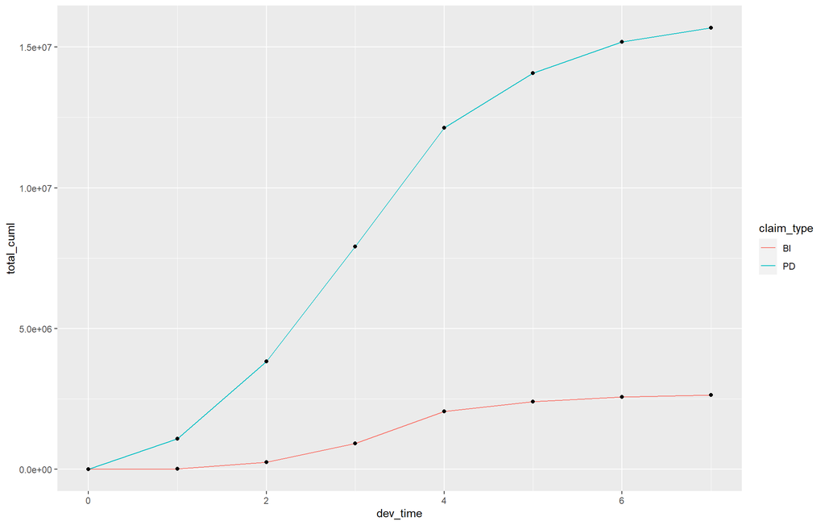

```r
plot_tbl <- claim_triangles_tbl %>%
  filter(country_code == 'IRL',
         claim_year   == 2010
         )

ggplot(plot_tbl) +
  geom_line (aes(x = dev_time, y = total_cuml, colour = claim_type)) +
  geom_point(aes(x = dev_time, y = total_cuml), colour = 'black')
```

In a plot like these, we can set the default `aes()` values inside the `ggplot()` call:

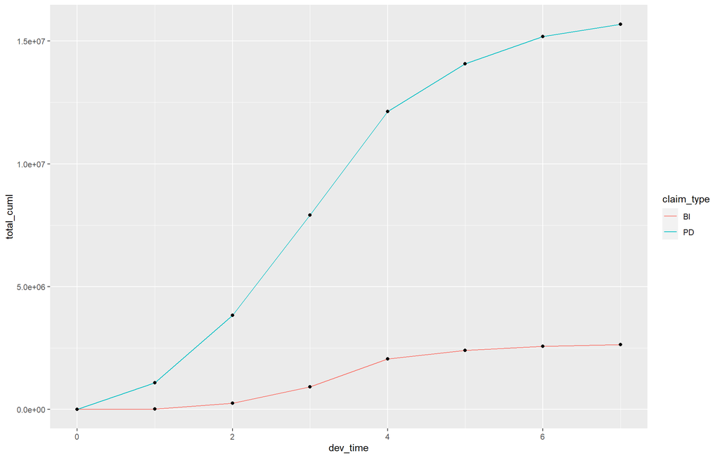

```r
ggplot(plot_tbl, aes(x = dev_time, y = total_cuml)) +
  geom_line (aes(colour = claim_type)) +
  geom_point(colour = 'black')
```

### 1.2.3 Labels and Titles

A good visualisation is one that requires little in the way of additional explanation - it tells its own story.

To do this we often want to improve a plot by labelling axes, adding titles, changing colour schemes and so on.

`xlab()`, `ylab()` and `ggtitle()` add a label to the x-axis, a label to the y-axis and a title to the plot respectively.

To show this, let’s look at lineplot of the aggregate development again:

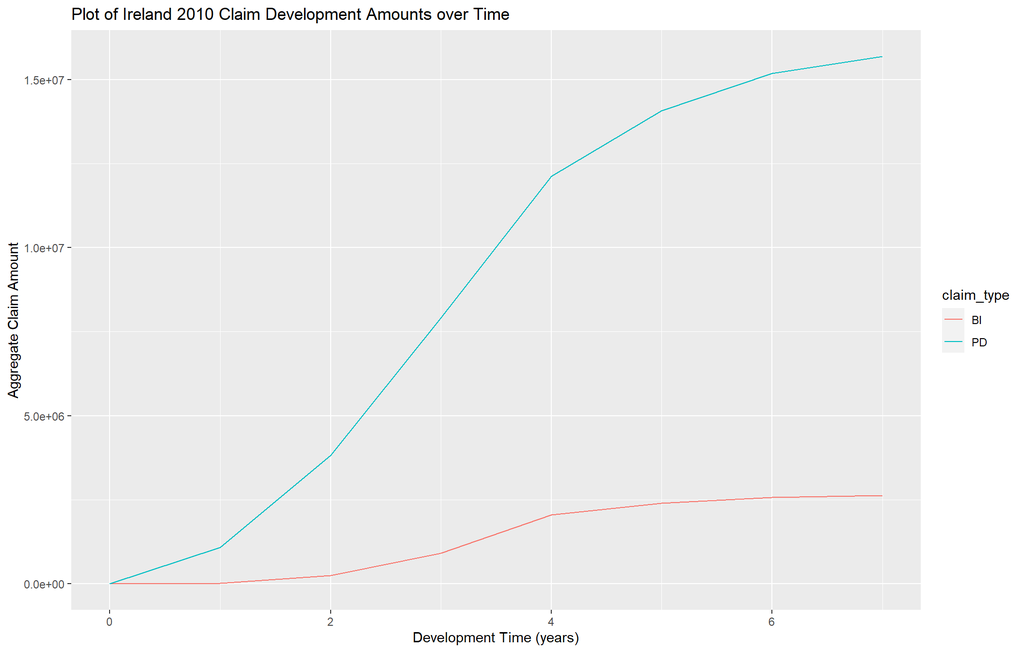

```r
plot_tbl <- claim_triangles_tbl %>%
  filter(country_code == 'IRL',
         claim_year   == 2010
         )

ggplot(plot_tbl) +
  geom_line (aes(x = dev_time, y = total_cuml, colour = claim_type)) +
  xlab('Development Time (years)') +
  ylab('Aggregate Claim Amount') +
  ggtitle('Plot of Ireland 2010 Claim Development Amounts over Time')
```

### 1.2.4 Themes

`ggplot2` is hugely customisable - almost everything about a plot can be edited. A simple way to exploit this is through the use of ‘themes’ - preset configurations to help you customise your plot.

A number of themes come with `ggplot2` and there are packages that add many more.

To show this feature, we use our existing plot with a number of different themes.

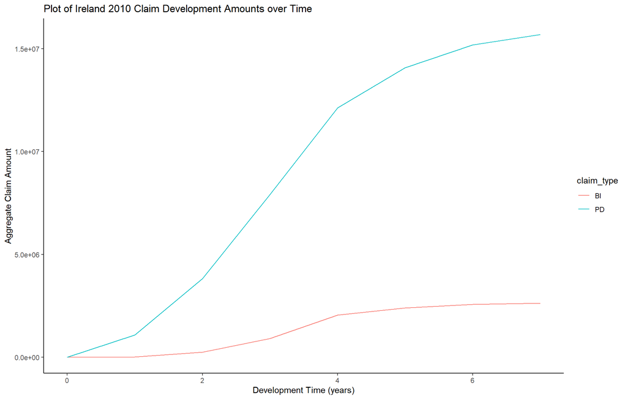

```r
plot_tbl <- claim_triangles_tbl %>%
  filter(country_code == 'IRL',
         claim_year   == 2010
         )

theme_plot <- ggplot(plot_tbl) +
  geom_line (aes(x = dev_time, y = total_cuml, colour = claim_type)) +
  xlab('Development Time (years)') +
  ylab('Aggregate Claim Amount') +
  ggtitle('Plot of Ireland 2010 Claim Development Amounts over Time')


theme_plot + theme_classic()
```

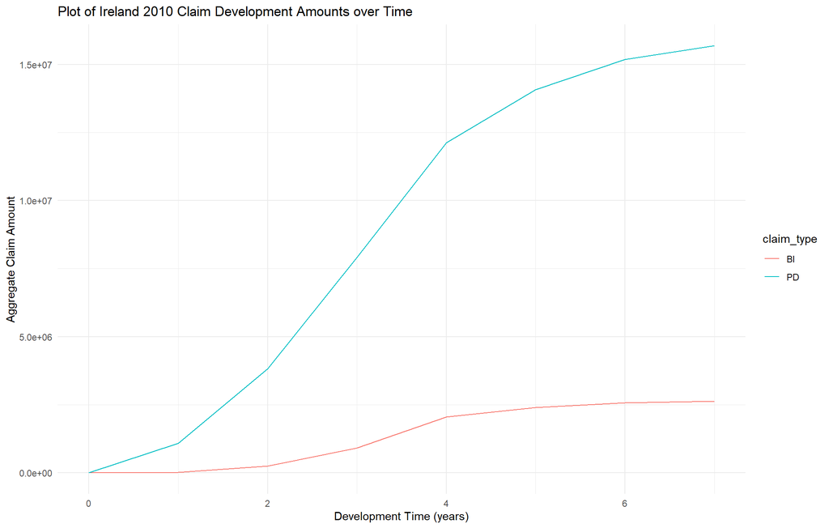

```r
theme_plot + theme_minimal()
```

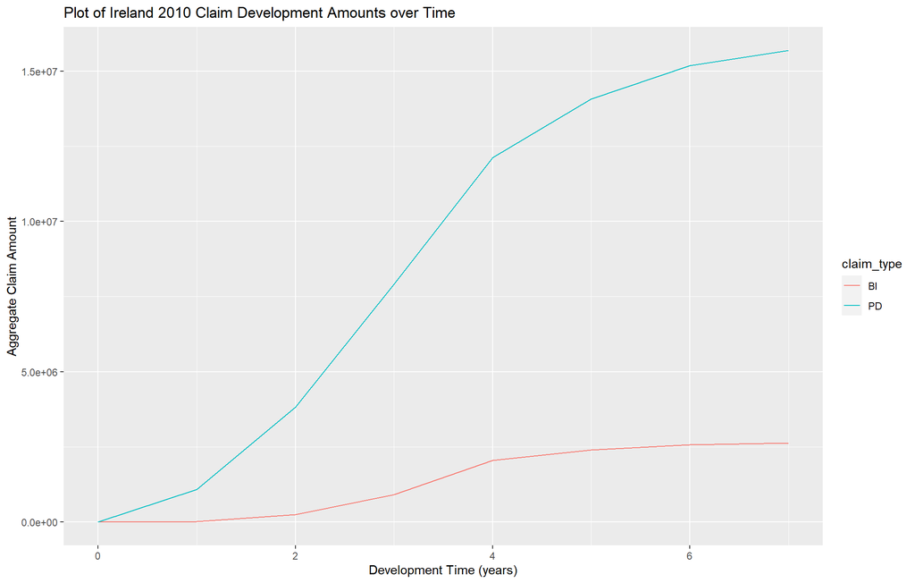

```r
theme_plot + theme_grey()
```

### 1.2.5 Ranges and Scales

One final concern is the range of values displayed on the x and y axis - we may wish to control what that range is, and how it is displayed.

We start by relabelling the current amounts by using commas - we use the `commas()` function from the `scales` package.

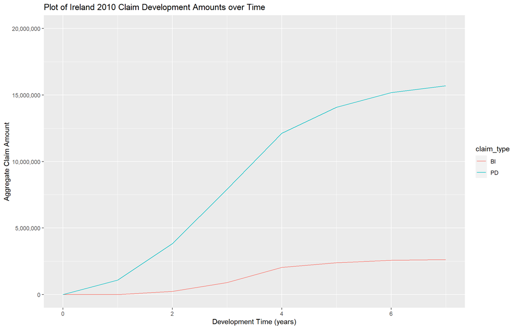

```r
plot_tbl <- claim_triangles_tbl %>%
  filter(country_code == 'IRL',
         claim_year   == 2010
         )

ggplot(plot_tbl) +
  geom_line (aes(x = dev_time, y = total_cuml, colour = claim_type)) +
  scale_y_continuous(labels = comma, limits = c(0, 20e6)) +
  xlab('Development Time (years)') +
  ylab('Aggregate Claim Amount') +
  ggtitle('Plot of Ireland 2010 Claim Development Amounts over Time')
```

We can use scales to transform variables (like use of a log-scale)

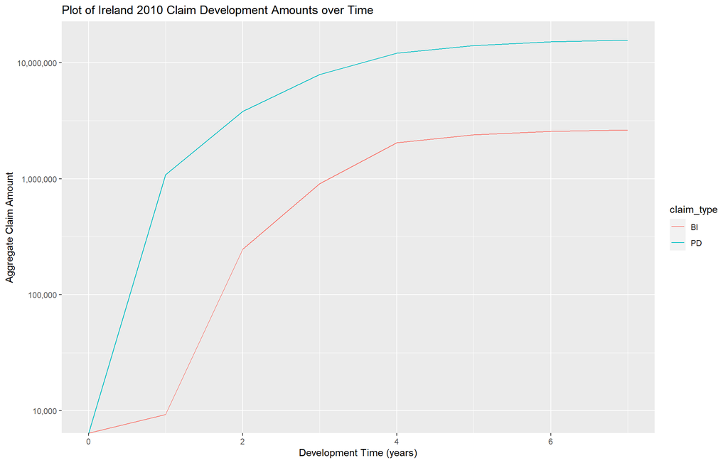

```r
plot_tbl <- claim_triangles_tbl %>%
  filter(country_code == 'IRL',
         claim_year   == 2010
         )

ggplot(plot_tbl) +
  geom_line (aes(x = dev_time, y = total_cuml, colour = claim_type)) +
  scale_y_log10(labels = comma) +
  xlab('Development Time (years)') +
  ylab('Aggregate Claim Amount') +
  ggtitle('Plot of Ireland 2010 Claim Development Amounts over Time')
```

We may want to ensure that certain values are included in the range of values.

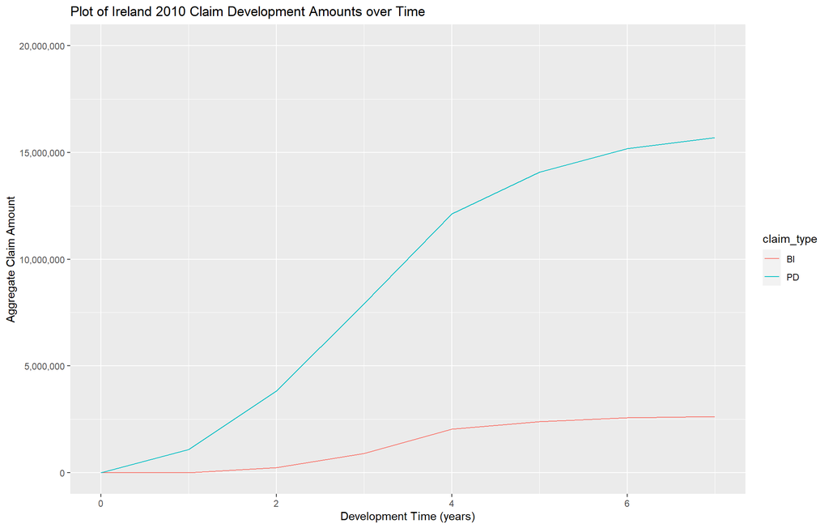

```r
ggplot(plot_tbl) +
  geom_line (aes(x = dev_time, y = total_cuml, colour = claim_type)) +
  scale_y_continuous(labels = comma, limits = c(0, 20e6)) +
  xlab('Development Time (years)') +
  ylab('Aggregate Claim Amount') +
  ggtitle('Plot of Ireland 2010 Claim Development Amounts over Time')
```